[figure not shown]

[figure not shown]

# Introduction

### Introduction

This dashboard is a part of USF project in Clark University, and we want to answer to the question “Are Neighborhoods with Public Housing Projects Brighter?” using Providence RI as a case study.

#### Datasets

Here is a list of datasets that will be used

- Artificial Light at Night (ALAN) Radiance Data from [NASA](https://www.earthdata.nasa.gov/learn/backgrounders/nighttime-lights)
- NDVI in May 2023 from [Landsat8](https://www.usgs.gov/landsat-missions/landsat-8)
- Population Data in 2020 from [Census Data](https://www.census.gov)
- Public Housing Data updated in 2023 from [HUD](https://www.huduser.gov/portal/datasets/assthsg.html#2009-2022_data)
- Building Footprint Data from [RI GIS Portal](https://www.rigis.org/datasets/building-footprints)

#### Workflow

This study will follow [a previous study](https://github.com/agroimpacts/USFlite/blob/main/external/notebooks/nightlights-part2.md) done by Dr. Estes et al at Clark University, and this will:

1. Plotting rasters of the variables
2. Exploring relations between the ALAN radiance and the other variables using scatter plot and linear regression line
3. Comparing medians of the ALAN radiance from cells, which have similar population, between with/ without public housings.

Additionally, I will try to create cross- tabulation map of the classification of the light and population.

The project was mainly done with [the R Language (R Core Team, 2022)](https://www.R-project.org/).

## Column2

### Basic Maps

[interactive chart not shown]

# Result

## Column1

### Description

#### CrossTab

This showed the a tabulation of estimated population and the ALAN radiance. Here are some findings:

- High/ High overlaps distributed across north and south of the center.
  - We can see some clusters there.
- Areas with small population but high ALAN radiance are shown along the riverside/ waterfront.
  - These could be commercial districts.
  - Interestingly, some public housings are located in the area.

#### Box Plot: Comparison of Medians

This section compares the ALAN radiance from grids having similar size of population between with/ without public housings. Although the number of those with public housings are smaller, their median is larger in 4 classes out of 5.

## Column2

### CrossTab

[interactive chart not shown]

### Box Plot: Comparison of Medians

Note that the values are scaled.

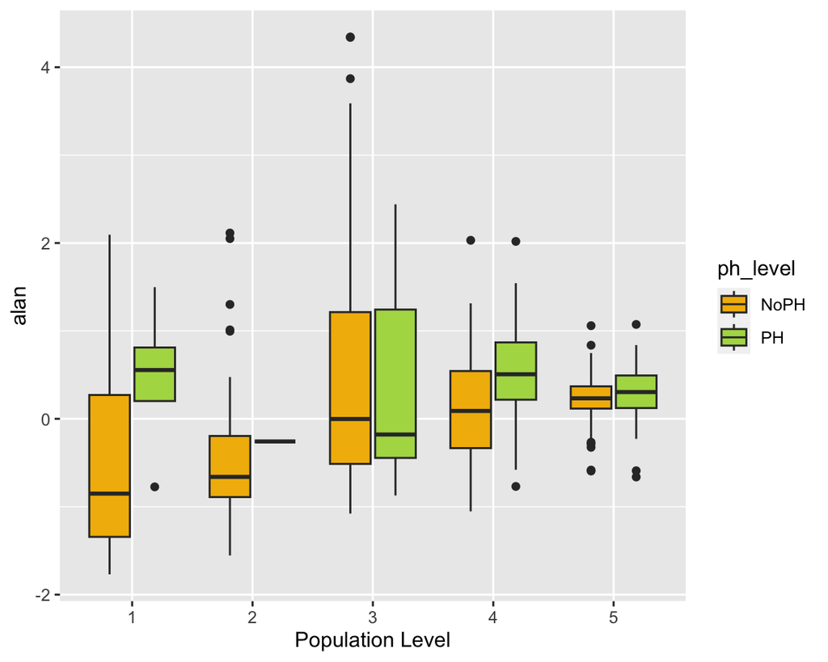

### Correlations

Note that the values are scaled.

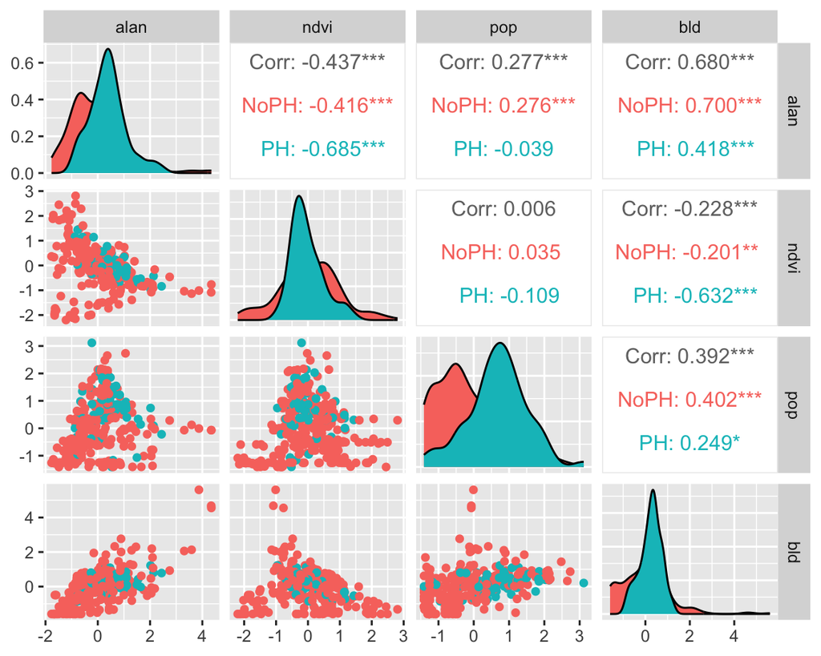